# Donor Profile: Netherlands - Ministry of Foreign Affairs

## Focus Portfolio

The Netherlands Ministry of Foreign Affairs portfolio highlights a critical funding concentration pattern across six UNHCR regions. While average donor funding is $7.6 million, with a significant peak of $40.9 million, this uneven distribution exposes both risk and opportunity. Regions with concentrated funding excel in program delivery, offering a proven impact multiplier for donor investments focused on scalability and emergency response. However, regions at the lower quartile around $2 million show vulnerability, signaling potential gaps in resilience and accountability. Prioritizing strategic partnerships in underfunded regions can unlock untapped impact and diversify risk. We recommend leveraging this data to invest in balanced resource allocation and innovative funding models that bridge disparities, driving systemic transformation. Donors committed to maximizing ROI should act now to scale successful interventions while closing critical funding gaps.

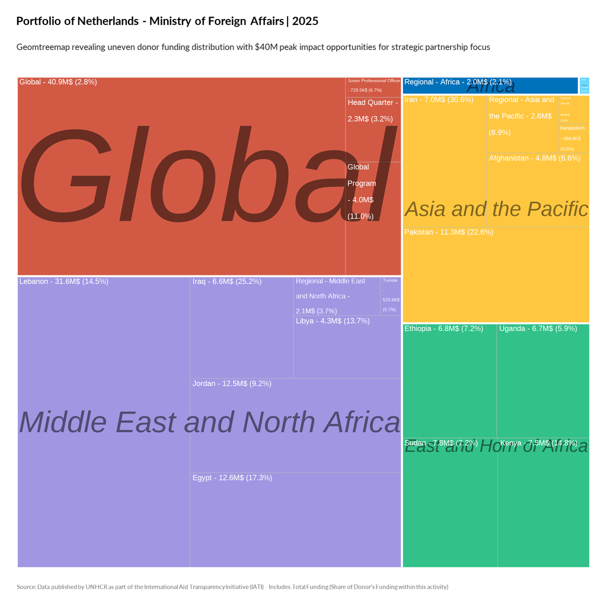

TRUE

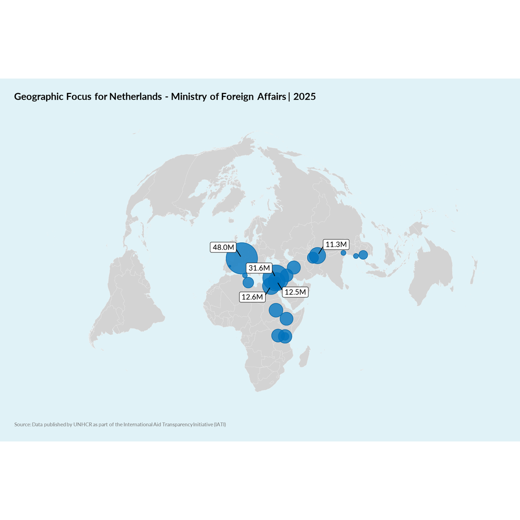

TRUE